# Serological investigation of Lassa mammarenavirus among rodent species in Eastern Sierra Leone.

David Simons

The Royal Veterinary College, London, UK

2022-09-13

# Introduction

Lassa fever caused by *Lassa mammarenavirus* is an endemic zoonotic disease with an between 100,000-900,000 annual infections (McCormick et al. 1987; Basinski et al. 2021). Asymptomatic infection is thought to be common (up to 80%), although individuals with severe symptoms requiring hospitalisation have generally poor outcomes with mortality in this group reported as 15%. The majority of annually reported cases come from Nigeria, where the Nigerian Centre for Disease Control have rapidly expanded access to testing and centralised reporting of Lassa fever cases. Cases are also reported from the Mano River Valley countries of Guinea, Liberia and Sierra Leone, where testing is less available and reporting more sporadic. Within the countries reporting Lassa fever cases there is important spatial clustering of cases, typically from rural areas. Lassa fever outbreaks also demonstrate temporal variability. In Nigeria reported cases peak in the first 3 months of the year, with low numbers of cases reported throughout the remaining periods, these patterns are less clear in the Western endemic countries with no consistent temporal association with a peak in reported cases.

Human infections are associated with spillover from rodent hosts, with limited human-to-human transmission reported. The primary host is *Mastomys natalensis* a commensal, native, rodent species present throughout sub-Saharan Africa. These rodents do not develop any clinical symptoms following infection with *Lassa mammarenavirus* and are susceptible to low infectious doses consistent with what might be obtained from a wound from an infected conspecific (Safronetz et al. 2022). Viral RNA is detectable 3 days postinfection, peaking within 1 to 2 weeks and resolving within approximately 40 days, however, RNA persistance was observed in testes beyond this point, prolonged sexual transmission may therefore exist. Based on a similar arenavirus (Morogoro virus), seroconversion is expected to occur 7 days post infection, with detectable antibodies remaining beyond the point in which circulating RNA has declined, therefore seroprevalence is a useful measure of pathogen existence within a location. Transmission, between individuals was found to occur through both contaminated fomites and direct contact, presenting two methods driving sustained pathogen transmission in endemic areas.

Despite *M. natalensis* being identified as the primary reservoir, 13 other rodent species have been identified to be acutely or previously infected with *Lassa mammarenavirus* in the endemic zone. The contribution of these species to pathogen spillover, viral transmission and maintenance is unknown. The high contact rates between rodents in species rich environments may produce incidental infections of non-reservoir species which subsequently get detect through surveillance activities while having little impact on viral transmission. Alternatively, these species may act to transfer this pathogen spatially and link *M. natalensis* populations that would not come into contact otherwise. It is therefore important to characterise rodent networks within endemic settings, rather than limiting investigation to a single rodent population.

The composition of rodent networks and the interaction between different rodent species in Lassa fever endemic regions has not been systematically reported. Previous studies have limited description of the wider rodent populations to measures of species richness and diversity. Additional information on the temporal and spatial overlap of individuals to infer potential for contact between individuals and importantly the risk of transmission of zoonotic pathogens, including *Lassa mammarenavirus*, is important. Pathogens typically persist in dense, well-connected networks. In discontinuous networks, pathogens with limited environmental transmission will die out as the number of susceptible individuals is rapidly depleted. We hypothesise that rodent contact rates would be greater in peri-urban settings where nutritional resources are more concentrated than in less anthropogenically modified landuse types. We further hypothesise that commensal rodent species, including *M. natalensis*, will have higher contact rates than non-commensal species such as *Praomys spp.*. It is expected that rodents with high connectivity to other individuals will be associated with antibody positivity for *Lassa mammarenavirus*.

# Methods

## Study area

We conducted rodent trapping at 7 trapping sites within 5 villages in the Lassa fever endemic zone of the Eastern Province of Sierra Leone. We surveyed the rodent community in forested, fallow, agricultural and areas of human occupation (within and outside of homes) along an anthropogenic land use gradient. Current land-use was classified at the level of trapping site as Agriculture, Fallow-land and Forested. Traps placed within villages were further defined as being within human dwellings (Village inside) and outside of permanent structures (Village outside). The village sites were enrolled based on accessibility to the sites during all seasons, discussions with the Lassa fever outreach team at Kenema Government Hospital and acceptability of the protocol to the village community. Villages and trapping sites were selected to be representative at the study level for land use in Eastern Sierra Leone. One of the villages, Bambawo, was only included for a single visit.

## How does landscape-, species- and individual-level heterogeneity influence contact networks?

Over a fixed period of time (here 40 days), a particular species pair either will or will not experience a contact sufficient to transmit *Lassa mammarenavirus*. As we consider a binary network of contact or no-contact, we produce a contact vector for the presence of contact between two species of (1 0) and no-contact (0 1). Generally, the $k$th observation is defined by the zero/one vector $d_{k,i,j}$. This vector specifies the presence or absence of contact that a unique pair of individuals of species $i$ and $j$ experienced over the time interval. We use this model to ask how attributes of the species and individuals involved in the interaction and the time period in which it took place affect the probability of a contact. This is done using a Multinomial contact model (Equation 1.)

$$\begin{align*}
d_k &\sim {\sf Multinomial}(N_k, p_{contact}, p_{no contact}) \\
{\sf log}(\frac{p_{contact}}{p_{no contact}}) & = X^{1} B^{1}
\end{align*}$$

## *Lassa mammarenavirus* serology

In a deviation from the kit description the optical density (OD) at 450nm and 630nm was measured (as opposed to 450nm and 620nm). The index value was produced from the OD difference (OD_450_ - OD_630_) divided by the cut-off values (the mean values of the negative controls + 0.150). Samples were considered positive with index values greater or equal to 1.1, negative results less than or equal to 0.9, and inconclusive results when the index value lay between 0.9 and 1.1. Inconclusive results were repeated as advised by the kit manufacturers.

## What is the prevalence of antibodies to *Lassa mammarenavirus* in an endemic setting in Sierra Leone?

We report the prevalence of antibodies to *Lassa mammarenavirus* in our trapped population. We explore how this varies between village study site, land-use type and species of rodent. To understand any fluctuation in prevalence we report on the temporal variation of seroprevalence in trapped rodents.

## Are *Lassa mammarenavirus* exposed rodents members of highly connected networks?

The networks produced for each land-use category were further subset to only include contacts between antibody positive individuals other co-located individuals. These sub-graphs were analysed using the same metrics as for the land-use graphs.

# Results

# Discussion

Future work should include testing these samples for acute viral infection using RT-PCR to understand the risk of viral transmission to humans.

# Supplementary

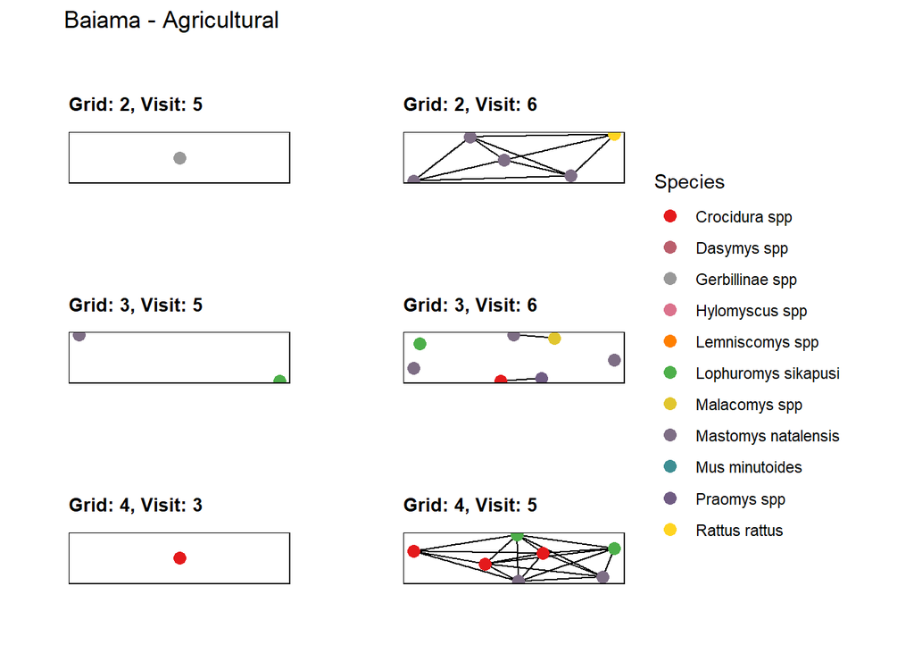

Basinski, Andrew J., Elisabeth Fichet-Calvet, Anna R. Sjodin, Tanner J. Varrelman, Christopher H. Remien, Nathan C. Layman, Brian H. Bird, et al. 2021. “Bridging the Gap: Using Reservoir Ecology and Human Serosurveys to Estimate Lassa Virus Spillover in West Africa.” Edited by Amy Wesolowski. *PLOS Computational Biology* 17 (3): e1008811. https://doi.org/10.1371/journal.pcbi.1008811.

Fichet-Calvet, Elisabeth. 2014. “Chapter 5 - Lassa Fever: A Rodent-Human Interaction.” In *The Role of Animals in Emerging Viral Diseases*, edited by Nicholas Johnson, 89–123. Boston: Academic Press. https://doi.org/10.1016/B978-0-12-405191-1.00005-3.

McCormick, J B, P A Webb, J W Krebs, K M Johnson, and E S Smith. 1987. “A Prospective Study of the Epidemiology and Ecology of Lassa Fever.” *The Journal of Infectious Diseases* 155 (3): 437–44. https://doi.org/10.1093/infdis/155.3.437.

Safronetz, David, Kyle Rosenke, Kimberley Meade-White, Angela Sloan, Ousmane Maiga, Sidy Bane, Cynthia Martellaro, Dana P Scott, Nafomon Sogoba, and Heinz Feldmann. 2022. “Temporal Analysis of Lassa Virus Infection and Transmission in Experimentally Infected Mastomys Natalensis.” *PNAS Nexus* 1 (3): pgac114. https://doi.org/10.1093/pnasnexus/pgac114.